| title: “test” |
| --- |
| output: html_document |
| date: “2025-02-13” |

```r
install.packages("htmltools", repos = "http://cran.rstudio.com/")
install.packages("sass", repos = "http://cran.rstudio.com/")
install.packages("bslib", repos = "http://cran.rstudio.com/")
library(fpp3)
```

```r
library(ggplot2)
library(patchwork)
library (forecast)
library(tidyverse)
library(gridExtra)
library(seasonal)
library(zoo)
library(USgas)
library(fable)
library(fabletools)
library(dplyr)
library(tsibble)
library(lattice)
library(feasts)
library(missMethods)
```

## 11.1 Consider the PBS data which has aggregation structure ATC1/ATC2 * Concession * Type.

## a. Produce plots of the aggregated Scripts data by Concession, Type and ATC1.

```r
print(PBS)
```

```
## # A tsibble: 67,596 x 9 [1M]
## # Key:       Concession, Type, ATC1, ATC2 [336]
##       Month Concession   Type      ATC1  ATC1_desc ATC2  ATC2_desc Scripts  Cost
##       <mth> <chr>        <chr>     <chr> <chr>     <chr> <chr>       <dbl> <dbl>
##  1 1991 Jul Concessional Co-payme… A     Alimenta… A01   STOMATOL…   18228 67877
##  2 1991 Aug Concessional Co-payme… A     Alimenta… A01   STOMATOL…   15327 57011
##  3 1991 Sep Concessional Co-payme… A     Alimenta… A01   STOMATOL…   14775 55020
##  4 1991 Oct Concessional Co-payme… A     Alimenta… A01   STOMATOL…   15380 57222
##  5 1991 Nov Concessional Co-payme… A     Alimenta… A01   STOMATOL…   14371 52120
##  6 1991 Dec Concessional Co-payme… A     Alimenta… A01   STOMATOL…   15028 54299
##  7 1992 Jan Concessional Co-payme… A     Alimenta… A01   STOMATOL…   11040 39753
##  8 1992 Feb Concessional Co-payme… A     Alimenta… A01   STOMATOL…   15165 54405
##  9 1992 Mar Concessional Co-payme… A     Alimenta… A01   STOMATOL…   16898 61108
## 10 1992 Apr Concessional Co-payme… A     Alimenta… A01   STOMATOL…   18141 65356
## # ℹ 67,586 more rows
```

Using PBSzeros ensures we completely remove entire drug categories that are never prescribed.

```r
# Any missing values in the Scripts column are replaced with 0.
PBS <- PBS |>
  fill_gaps(Scripts=0, .full=TRUE)

# Find series that are only 0s and exclude them.
PBSzeros <- PBS |>
  as_tibble() |>
  # Analyze each drug category separately.
  group_by(ATC1, ATC2, Concession, Type) |>
  # If all Scripts values for a drug category are 0 across all time periods, mean(abs(Scripts)) will also be 0.
  summarise(mas = mean(abs(Scripts))) |>
  # Keeps only those groups where Scripts was always 0.
  filter(mas==0)
# Removes any drug categories that were always 0, ensuring that only meaningful prescription data remains.
PBS <- PBS |>
  anti_join(PBSzeros)
print(PBS)
```

```
## # A tsibble: 68,136 x 9 [1M]
## # Key:       Concession, Type, ATC1, ATC2 [334]
##       Month Concession   Type      ATC1  ATC1_desc ATC2  ATC2_desc Scripts  Cost
##       <mth> <chr>        <chr>     <chr> <chr>     <chr> <chr>       <dbl> <dbl>
##  1 1991 Jul Concessional Co-payme… A     Alimenta… A01   STOMATOL…   18228 67877
##  2 1991 Aug Concessional Co-payme… A     Alimenta… A01   STOMATOL…   15327 57011
##  3 1991 Sep Concessional Co-payme… A     Alimenta… A01   STOMATOL…   14775 55020
##  4 1991 Oct Concessional Co-payme… A     Alimenta… A01   STOMATOL…   15380 57222
##  5 1991 Nov Concessional Co-payme… A     Alimenta… A01   STOMATOL…   14371 52120
##  6 1991 Dec Concessional Co-payme… A     Alimenta… A01   STOMATOL…   15028 54299
##  7 1992 Jan Concessional Co-payme… A     Alimenta… A01   STOMATOL…   11040 39753
##  8 1992 Feb Concessional Co-payme… A     Alimenta… A01   STOMATOL…   15165 54405
##  9 1992 Mar Concessional Co-payme… A     Alimenta… A01   STOMATOL…   16898 61108
## 10 1992 Apr Concessional Co-payme… A     Alimenta… A01   STOMATOL…   18141 65356
## # ℹ 68,126 more rows
```

```r
# aggregate_key() aggregates data across different hierarchical levels in the dataset.
# Sum all Scripts for each ATC1
# Sum Scripts within each ATC2 level for a given ATC1
# Within each ATC1/ATC2, it further sums Scripts by Concession and Type.

PBS_gts<- PBS |>
  aggregate_key(ATC1/ATC2 * Concession * Type, Scripts = sum(Scripts))
```

```r
print(PBS_gts)
```

```
## # A tsibble: 183,192 x 6 [1M]
## # Key:       ATC1, Concession, Type, ATC2 [898]
##       Month ATC1         Concession   Type         ATC2         Scripts
##       <mth> <chr*>       <chr*>       <chr*>       <chr*>         <dbl>
##  1 1991 Jul <aggregated> <aggregated> <aggregated> <aggregated> 8090395
##  2 1991 Aug <aggregated> <aggregated> <aggregated> <aggregated> 7308118
##  3 1991 Sep <aggregated> <aggregated> <aggregated> <aggregated> 7614644
##  4 1991 Oct <aggregated> <aggregated> <aggregated> <aggregated> 8206248
##  5 1991 Nov <aggregated> <aggregated> <aggregated> <aggregated> 7686634
##  6 1991 Dec <aggregated> <aggregated> <aggregated> <aggregated> 8954872
##  7 1992 Jan <aggregated> <aggregated> <aggregated> <aggregated> 9616464
##  8 1992 Feb <aggregated> <aggregated> <aggregated> <aggregated> 6291465
##  9 1992 Mar <aggregated> <aggregated> <aggregated> <aggregated> 6806613
## 10 1992 Apr <aggregated> <aggregated> <aggregated> <aggregated> 7651435
## # ℹ 183,182 more rows
```

Plot Aggregated Scripts by ATC1

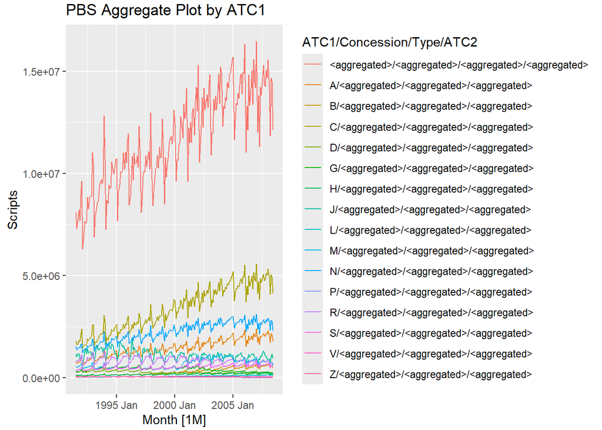

```r
# The line plot shows the total Scripts for each ATC1 category over time.
# Keeps only rows where Concession, Type, and ATC2 are fully aggregated.
# This results in ATC1-level total prescription data.

PBS_gts %>%
  # The dataset is now aggregated only at the ATC1 level (higher-level classification of drugs), summing Scripts across ATC2, Concession, and Type.
  filter(is_aggregated(Concession), is_aggregated(Type),
         is_aggregated(ATC2)) %>%
  autoplot(Scripts)+
  labs(title = "PBS Aggregate Plot by ATC1") +
  theme(plot.margin = margin(0.1, 0.2, 0.1, 0.2, "cm"))  # Expands margins
```

Plot Aggregated Scripts by ATC1 (ATC2 Breakdown)

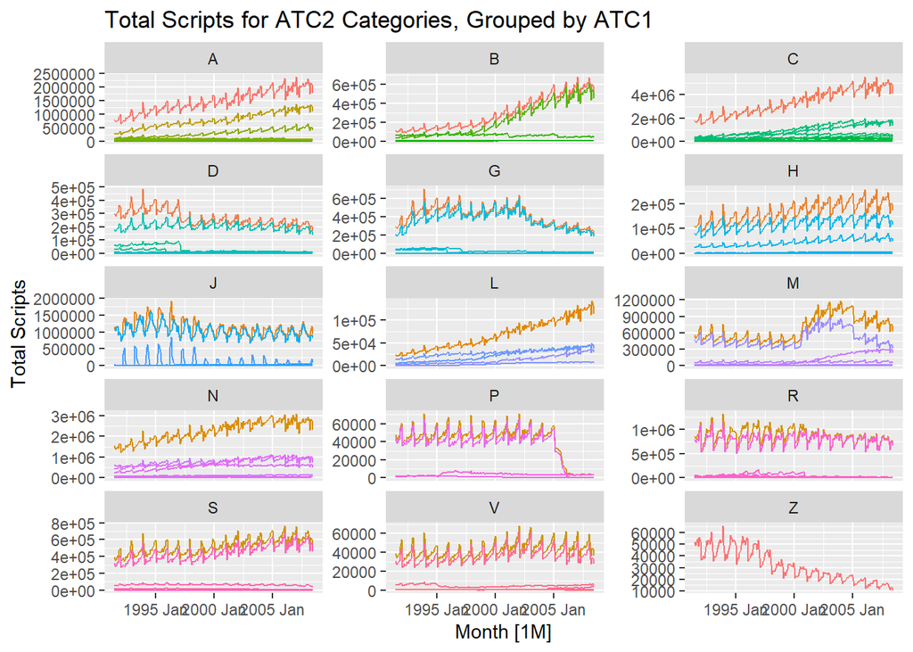

```r
# The dataset now contains ATC2-level prescription data, while Concession and Type are fully aggregated.
# Each ATC1 drug classification gets its own subplot, displaying ATC2-level trends.
# ATC2 prescription trends are shown inside each ATC1 panel.
# Analyze prescription trends across different drug classes (ATC1) while maintaining ATC2-level details.
# Time Series of Total Scripts by ATC1 (ATC2 Breakdown, Aggregated Concession & Type)

PBS_gts %>%
  filter(is_aggregated(Concession), is_aggregated(Type),
         !is_aggregated(ATC1)) %>%
  autoplot(Scripts) +
  facet_wrap(vars(ATC1), scales = "free_y", ncol = 3) +
  labs(y = "Total Scripts",
       title = "Total Scripts for ATC2 Categories, Grouped by ATC1") +
  theme(legend.position =  "none")
```

Plot Aggregated Scripts by Concession (Keeping Concession Details)

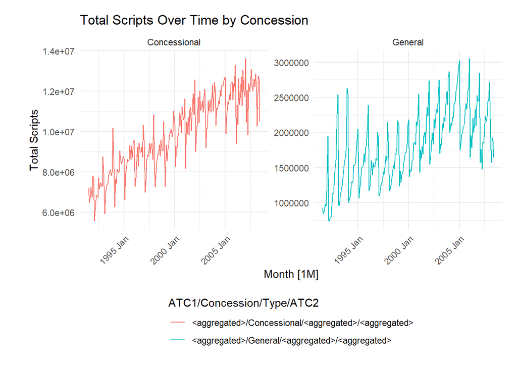

```r
# Keeps individual Concession categories (does not aggregate them).
# Aggregates Type and ATC1 (removes their details).
# Facets by Concession to visualize trends across different concession types.

PBS_gts %>%
  filter(!is_aggregated(Concession), is_aggregated(Type), is_aggregated(ATC1)) %>%
  autoplot(Scripts) +
  facet_wrap(vars(Concession), scales = "free_y", ncol = 2) +  # Arrange in 2 columns for better spacing
  labs(title = "Total Scripts Over Time by Concession",
       y = "Total Scripts") +
  theme_minimal() +
  theme(legend.position = "bottom",  # Moves legend below the plot
        legend.direction = "vertical",  # Aligns legend items vertically
        plot.margin = margin(0.5, 0.5, 0.5, 1, "cm"),  # Adds more space on the left
        axis.text.x = element_text(angle = 45, hjust = 1))  # Rotates x-axis labels for better readability
```

Plot Aggregated Scripts by Type (Keeping Type Details)

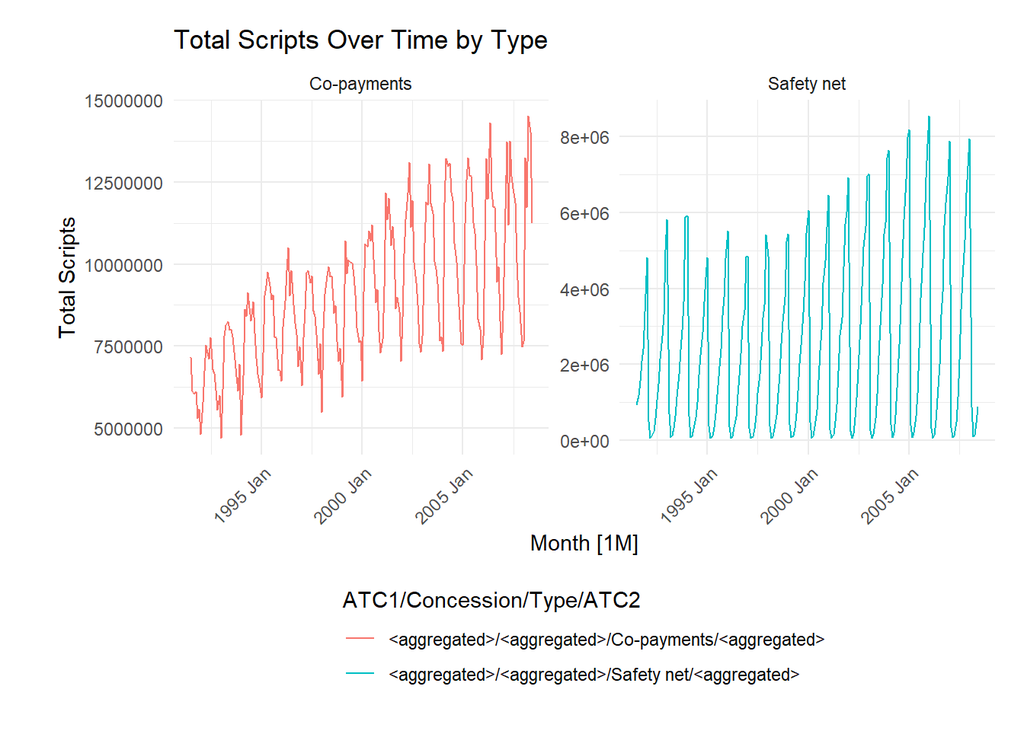

```r
# Keeps individual Type categories (does not aggregate them).
# Aggregates Concession and ATC1 (removes their details).
# Facets by Type to visualize trends across different payment types.

PBS_gts %>%
  filter(is_aggregated(Concession), !is_aggregated(Type), is_aggregated(ATC1)) %>%
  autoplot(Scripts) +
  facet_wrap(vars(Type), scales = "free_y", ncol = 2) +  # Arrange in 2 columns for better spacing
  labs(title = "Total Scripts Over Time by Type",
       y = "Total Scripts") +
  theme_minimal() +
  theme(legend.position = "bottom",  # Moves legend below the plot
        legend.direction = "vertical",  # Aligns legend items vertically
        plot.margin = margin(0.5, 0.5, 0.5, 1, "cm"),  # Adds more space on the left
        axis.text.x = element_text(angle = 45, hjust = 1))  # Rotates x-axis labels for better readability
```

## b. Forecast the PBS Scripts data using ETS, ARIMA and SNAIVE models, applied to all but the last three years of data.

## ETS model

```r
ets_base <- PBS_gts |>
  filter(Month < max(Month)-36) |>
  model(ets = ETS(Scripts))

forecast_ets_base <-
  ets_base |>
  forecast(h = 36)

print(forecast_ets_base)
```

```
## # A fable: 32,328 x 8 [1M]
## # Key:     ATC1, Concession, Type, ATC2, .model [898]
##    ATC1   Concession   Type        ATC2   .model    Month
##    <chr*> <chr*>       <chr*>      <chr*> <chr>     <mth>
##  1 A      Concessional Co-payments A01    ets    2005 Jun
##  2 A      Concessional Co-payments A01    ets    2005 Jul
##  3 A      Concessional Co-payments A01    ets    2005 Aug
##  4 A      Concessional Co-payments A01    ets    2005 Sep
##  5 A      Concessional Co-payments A01    ets    2005 Oct
##  6 A      Concessional Co-payments A01    ets    2005 Nov
##  7 A      Concessional Co-payments A01    ets    2005 Dec
##  8 A      Concessional Co-payments A01    ets    2006 Jan
##  9 A      Concessional Co-payments A01    ets    2006 Feb
## 10 A      Concessional Co-payments A01    ets    2006 Mar
## # ℹ 32,318 more rows
## # ℹ 2 more variables: Scripts <dist>, .mean <dbl>
```

Use Concessional panel below as an example -

The top line is the total prescription volume for Concessional. The smaller lines are subcategories (ATC1/ATC2) contributing to that total. The patterns show seasonality and trends, with some categories contributing significantly more than others.

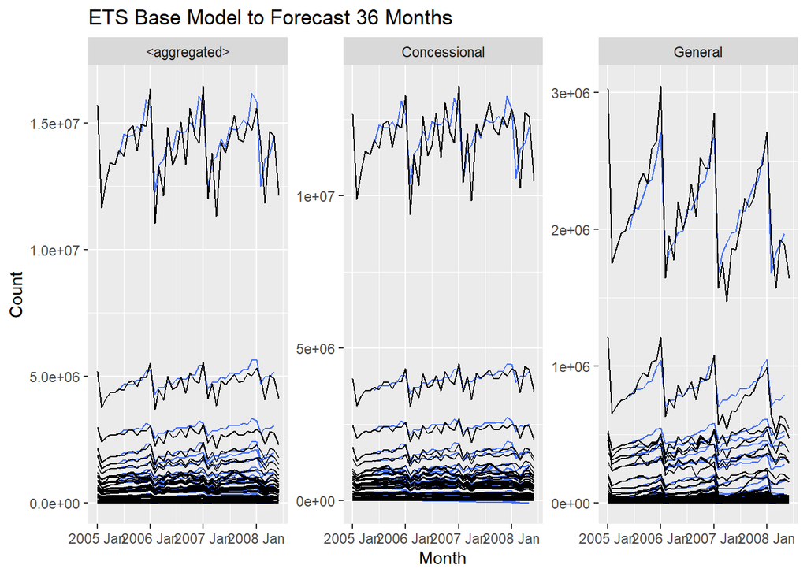

```r
forecast_ets_base %>%
  filter(is_aggregated(Type)) %>%  # Keep it aggregated only by Type, not by Concession
  autoplot(
    PBS_gts %>% filter(year(Month) >= 2005),
    level = NULL
  ) +
  labs(y = "Count", title = "ETS Base Model to Forecast 36 Months") +
  facet_wrap(vars(Concession), scales = "free_y")  # Now it should work!
```

```r
forecast_ets_base %>%
  accuracy(PBS_gts, measures = list(rmsse = RMSSE, mase = MASE)) %>%
  # After calculating RMSSE and MASE for each individual time series, it takes the mean across all series to provide an overall performance summary for each model (Mint_ets vs. ets).
  group_by(.model) %>%
  summarise(rmsse = mean(rmsse), mase = mean(mase))
```

```
## # A tibble: 1 × 3
##   .model rmsse  mase
##   <chr>  <dbl> <dbl>
## 1 ets     2.60  4.15
```

## ARIMA model

```r
arima_base <-
  PBS_gts %>%
  filter(Month < max(Month)-36) %>%
  model(arima = ARIMA(Scripts))
```

[output not shown]

[output cut: 16 more lines]

[output not shown]

```r
forecast_arima_base <-
  arima_base %>%
  forecast(h = 36)

print(forecast_arima_base)
```

```
## # A fable: 32,328 x 8 [1M]
## # Key:     ATC1, Concession, Type, ATC2, .model [898]
##    ATC1   Concession   Type        ATC2   .model    Month
##    <chr*> <chr*>       <chr*>      <chr*> <chr>     <mth>
##  1 A      Concessional Co-payments A01    arima  2005 Jun
##  2 A      Concessional Co-payments A01    arima  2005 Jul
##  3 A      Concessional Co-payments A01    arima  2005 Aug
##  4 A      Concessional Co-payments A01    arima  2005 Sep
##  5 A      Concessional Co-payments A01    arima  2005 Oct
##  6 A      Concessional Co-payments A01    arima  2005 Nov
##  7 A      Concessional Co-payments A01    arima  2005 Dec
##  8 A      Concessional Co-payments A01    arima  2006 Jan
##  9 A      Concessional Co-payments A01    arima  2006 Feb
## 10 A      Concessional Co-payments A01    arima  2006 Mar
## # ℹ 32,318 more rows
## # ℹ 2 more variables: Scripts <dist>, .mean <dbl>
```

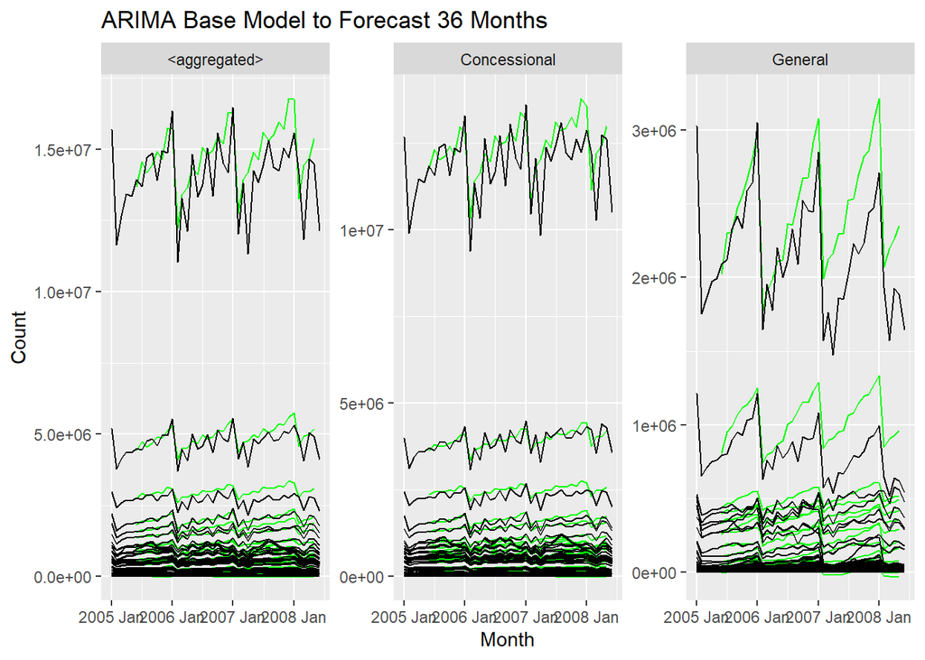

```r
forecast_arima_base %>%
  filter(is_aggregated(Type)) %>%
  autoplot(
    PBS_gts %>%
      filter(year(Month) >= 2005),
    level = NULL,
    color = "green"
  ) +
  labs(y = "Count", title = "ARIMA Base Model to Forecast 36 Months") +
  facet_wrap(vars(Concession), scales = "free_y")
```

```r
forecast_arima_base %>%
  accuracy(PBS_gts, measures = list(rmsse = RMSSE, mase = MASE)) %>%
  group_by(.model) %>%
  summarise(rmsse = mean(rmsse), mase = mean(mase))
```

```
## # A tibble: 1 × 3
##   .model rmsse  mase
##   <chr>  <dbl> <dbl>
## 1 arima   2.37  2.62
```

## SNAIVE model

```r
snaive_base <-
  PBS_gts %>%
  filter(Month < max(Month)-36) %>%
  model(snaive = SNAIVE(Scripts))

forecast_snaive_base <-
  snaive_base %>%
  forecast(h = 36)

print(forecast_snaive_base)
```

```
## # A fable: 32,328 x 8 [1M]
## # Key:     ATC1, Concession, Type, ATC2, .model [898]
##    ATC1   Concession   Type        ATC2   .model    Month
##    <chr*> <chr*>       <chr*>      <chr*> <chr>     <mth>
##  1 A      Concessional Co-payments A01    snaive 2005 Jun
##  2 A      Concessional Co-payments A01    snaive 2005 Jul
##  3 A      Concessional Co-payments A01    snaive 2005 Aug
##  4 A      Concessional Co-payments A01    snaive 2005 Sep
##  5 A      Concessional Co-payments A01    snaive 2005 Oct
##  6 A      Concessional Co-payments A01    snaive 2005 Nov
##  7 A      Concessional Co-payments A01    snaive 2005 Dec
##  8 A      Concessional Co-payments A01    snaive 2006 Jan
##  9 A      Concessional Co-payments A01    snaive 2006 Feb
## 10 A      Concessional Co-payments A01    snaive 2006 Mar
## # ℹ 32,318 more rows
## # ℹ 2 more variables: Scripts <dist>, .mean <dbl>
```

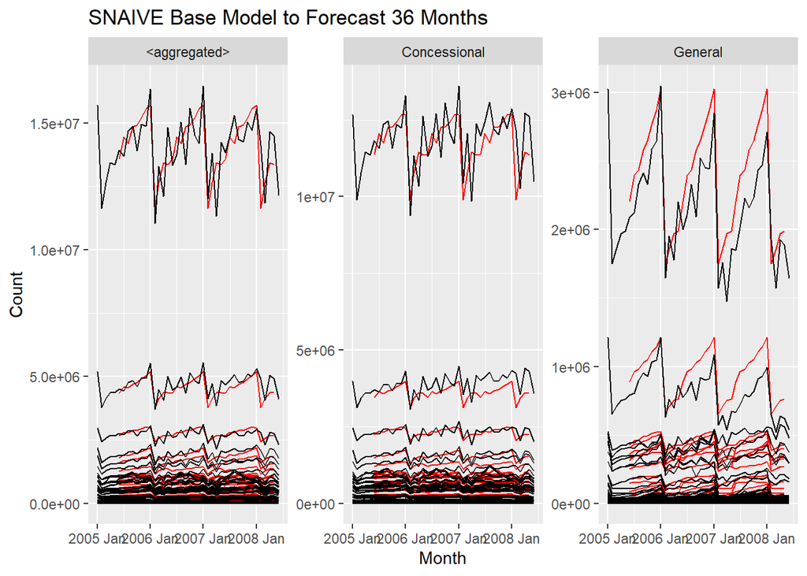

```r
forecast_snaive_base %>%
  filter(is_aggregated(Type)) %>%
  autoplot(
    PBS_gts %>% filter(year(Month) >= 2005),
    level = NULL,
    color = "red"
  ) +
  labs(y = "Count", title = "SNAIVE Base Model to Forecast 36 Months") +
  facet_wrap(vars(Concession), scales = "free_y")
```

```r
forecast_snaive_base %>%
  accuracy(PBS_gts, measures = list(rmsse = RMSSE, mase = MASE)) %>%
  group_by(.model) %>%
  summarise(rmsse = mean(rmsse), mase = mean(mase))
```

```
## # A tibble: 1 × 3
##   .model rmsse  mase
##   <chr>  <dbl> <dbl>
## 1 snaive  2.46  2.66
```

## c. Reconcile each of the forecasts using MinT.

## ETS model with MinT Forecast Method

forecast_ets_base = Base forecasts at original levels.

forecast_ets_mint_36 = Base + reconciled forecasts, leading to twice as many rows.

```r
ets_mint_model <-
  ets_base %>%
  reconcile(Mint_ets = min_trace(ets))

forecast_ets_mint_36 <-
  forecast(ets_mint_model, h = "3 years")

print(forecast_ets_mint_36)
```

```
## # A fable: 64,656 x 8 [1M]
## # Key:     ATC1, Concession, Type, ATC2, .model [1,796]
##    ATC1   Concession   Type        ATC2   .model    Month
##    <chr*> <chr*>       <chr*>      <chr*> <chr>     <mth>
##  1 A      Concessional Co-payments A01    ets    2005 Jun
##  2 A      Concessional Co-payments A01    ets    2005 Jul
##  3 A      Concessional Co-payments A01    ets    2005 Aug
##  4 A      Concessional Co-payments A01    ets    2005 Sep
##  5 A      Concessional Co-payments A01    ets    2005 Oct
##  6 A      Concessional Co-payments A01    ets    2005 Nov
##  7 A      Concessional Co-payments A01    ets    2005 Dec
##  8 A      Concessional Co-payments A01    ets    2006 Jan
##  9 A      Concessional Co-payments A01    ets    2006 Feb
## 10 A      Concessional Co-payments A01    ets    2006 Mar
## # ℹ 64,646 more rows
## # ℹ 2 more variables: Scripts <dist>, .mean <dbl>
```

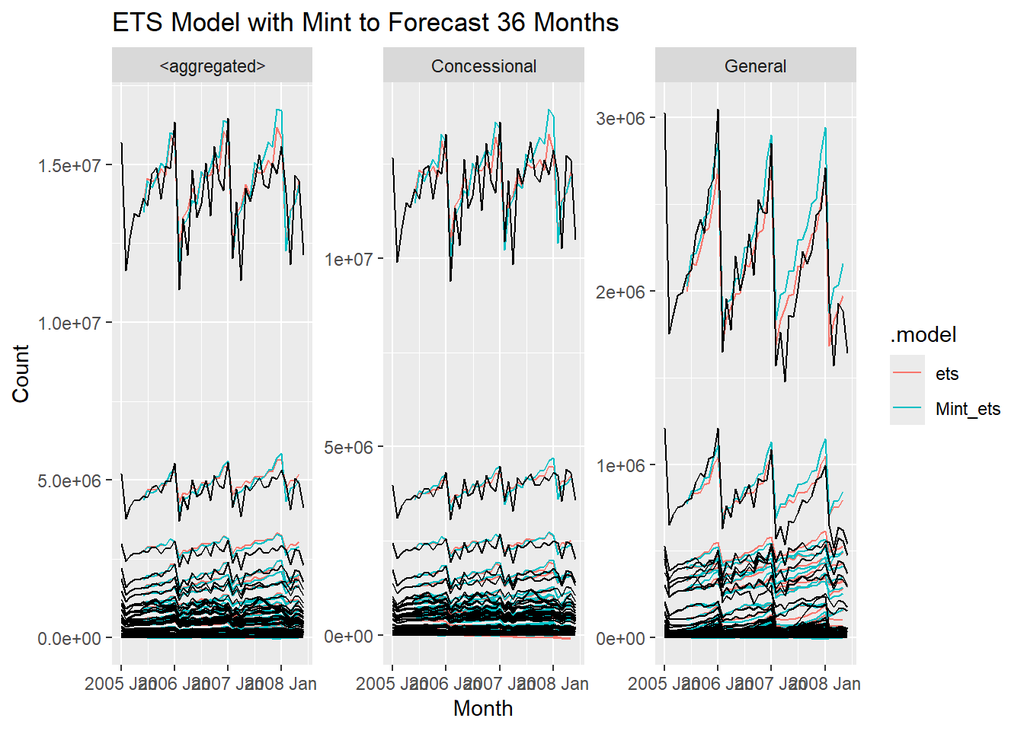

```r
forecast_ets_mint_36 %>%
  filter(is_aggregated(Type)) %>%
  autoplot(
    PBS_gts %>% filter(year(Month) >= 2005),
    level = NULL
  ) +
  labs(y = "Count", title = "ETS Model with Mint to Forecast 36 Months") +
  facet_wrap(vars(Concession), scales = "free_y")
```

```r
forecast_ets_mint_36 %>%
  accuracy(PBS_gts, measures = list(rmsse = RMSSE, mase = MASE)) %>%
  group_by(.model) %>%
  summarise(rmsse = mean(rmsse), mase = mean(mase))
```

```
## # A tibble: 2 × 3
##   .model   rmsse  mase
##   <chr>    <dbl> <dbl>
## 1 Mint_ets  2.53  3.60
## 2 ets       2.60  4.15
```

## ARIMA model with MinT Forecast Method

```r
arima_mint_model <-
  arima_base %>%
  reconcile(Mint_ARIMA = min_trace(arima))

forecast_arima_mint_36 <-
  arima_mint_model %>%
  forecast(h = 36)

print(forecast_arima_mint_36)
```

```
## # A fable: 64,656 x 8 [1M]
## # Key:     ATC1, Concession, Type, ATC2, .model [1,796]
##    ATC1   Concession   Type        ATC2   .model    Month
##    <chr*> <chr*>       <chr*>      <chr*> <chr>     <mth>
##  1 A      Concessional Co-payments A01    arima  2005 Jun
##  2 A      Concessional Co-payments A01    arima  2005 Jul
##  3 A      Concessional Co-payments A01    arima  2005 Aug
##  4 A      Concessional Co-payments A01    arima  2005 Sep
##  5 A      Concessional Co-payments A01    arima  2005 Oct
##  6 A      Concessional Co-payments A01    arima  2005 Nov
##  7 A      Concessional Co-payments A01    arima  2005 Dec
##  8 A      Concessional Co-payments A01    arima  2006 Jan
##  9 A      Concessional Co-payments A01    arima  2006 Feb
## 10 A      Concessional Co-payments A01    arima  2006 Mar
## # ℹ 64,646 more rows
## # ℹ 2 more variables: Scripts <dist>, .mean <dbl>
```

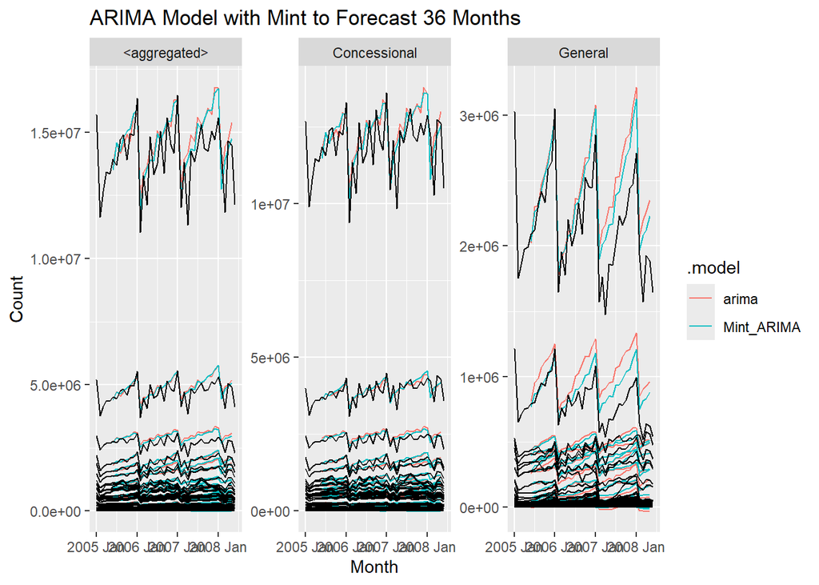

```r
forecast_arima_mint_36 %>%
  filter(is_aggregated(Type)) %>%
  autoplot(
    PBS_gts %>% filter(year(Month) >= 2005),
    level = NULL
  ) +
  labs(y = "Count", title = "ARIMA Model with Mint to Forecast 36 Months") +
  facet_wrap(vars(Concession), scales = "free_y")
```

```r
forecast_arima_mint_36 %>%
  accuracy(PBS_gts, measures = list(rmsse = RMSSE, mase = MASE)) %>%
  group_by(.model) %>%
  summarise(rmsse = mean(rmsse), mase = mean(mase))
```

```
## # A tibble: 2 × 3
##   .model     rmsse  mase
##   <chr>      <dbl> <dbl>
## 1 Mint_ARIMA  2.34  2.55
## 2 arima       2.37  2.62
```

## SNAIVE model with MinT Forecast Method

```r
snaive_mint_model <-
  snaive_base%>%
  reconcile(
    SNAIVE_Mint = min_trace(snaive)
  )

forecast_snaive_mint_36 <-
  snaive_mint_model %>%
  forecast(h = 36)

print(forecast_snaive_mint_36)
```

```
## # A fable: 64,656 x 8 [1M]
## # Key:     ATC1, Concession, Type, ATC2, .model [1,796]
##    ATC1   Concession   Type        ATC2   .model    Month
##    <chr*> <chr*>       <chr*>      <chr*> <chr>     <mth>
##  1 A      Concessional Co-payments A01    snaive 2005 Jun
##  2 A      Concessional Co-payments A01    snaive 2005 Jul
##  3 A      Concessional Co-payments A01    snaive 2005 Aug
##  4 A      Concessional Co-payments A01    snaive 2005 Sep
##  5 A      Concessional Co-payments A01    snaive 2005 Oct
##  6 A      Concessional Co-payments A01    snaive 2005 Nov
##  7 A      Concessional Co-payments A01    snaive 2005 Dec
##  8 A      Concessional Co-payments A01    snaive 2006 Jan
##  9 A      Concessional Co-payments A01    snaive 2006 Feb
## 10 A      Concessional Co-payments A01    snaive 2006 Mar
## # ℹ 64,646 more rows
## # ℹ 2 more variables: Scripts <dist>, .mean <dbl>
```

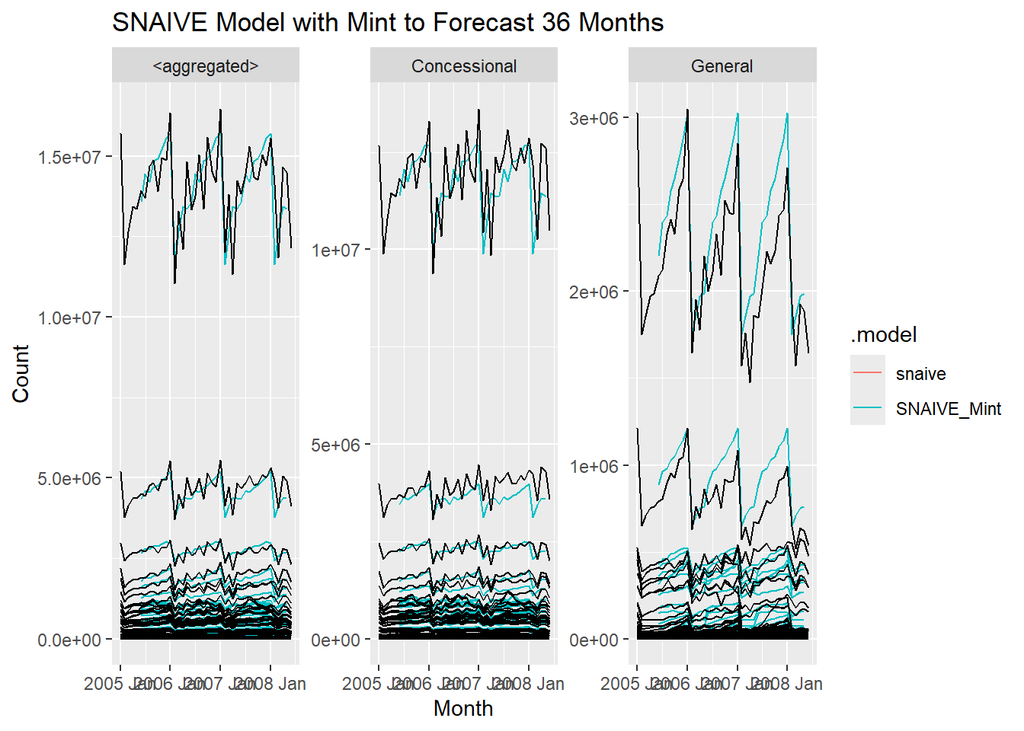

```r
forecast_snaive_mint_36 %>%
  filter(is_aggregated(Type)) %>%
  autoplot(
    PBS_gts %>% filter(year(Month) >= 2005),
    level = NULL
  ) +
  labs(y = "Count", title = "SNAIVE Model with Mint to Forecast 36 Months") +
  facet_wrap(vars(Concession), scales = "free_y")
```

```r
forecast_snaive_mint_36 %>%
  accuracy(PBS_gts, measures = list(rmsse = RMSSE, mase = MASE)) %>%
  group_by(.model) %>%
  summarise(rmsse = mean(rmsse), mase = mean(mase))
```

```
## # A tibble: 2 × 3
##   .model      rmsse  mase
##   <chr>       <dbl> <dbl>
## 1 SNAIVE_Mint  2.46  2.66
## 2 snaive       2.46  2.66
```

## d. Which type of model works best on the test set?

To identify the best model, we compare **RMSSE** and **MASE**, where lower values indicate better accuracy. After reconciliation, the **ARIMA model** achieves the lowest RMSSE (2.34) and MASE (2.55), making it the best performer on the test set.The reconciled ARIMA model is best overall.

```r
combined_model_results <- bind_rows(
  forecast_ets_mint_36 %>%
    accuracy(PBS_gts, measures = list(rmsse = RMSSE, mase = MASE)) %>%
    group_by(.model) %>%
    summarise(rmsse = mean(rmsse), mase = mean(mase)) %>%
    mutate(method = "ETS"),

  forecast_arima_mint_36 %>%
    accuracy(PBS_gts, measures = list(rmsse = RMSSE, mase = MASE)) %>%
    group_by(.model) %>%
    summarise(rmsse = mean(rmsse), mase = mean(mase)) %>%
    mutate(method = "ARIMA"),

  forecast_snaive_mint_36 %>%
    accuracy(PBS_gts, measures = list(rmsse = RMSSE, mase = MASE)) %>%
    group_by(.model) %>%
    summarise(rmsse = mean(rmsse), mase = mean(mase)) %>%
    mutate(method = "SNAIVE")
)

print(combined_model_results)
```

```
## # A tibble: 6 × 4
##   .model      rmsse  mase method
##   <chr>       <dbl> <dbl> <chr>
## 1 Mint_ets     2.53  3.60 ETS
## 2 ets          2.60  4.15 ETS
## 3 Mint_ARIMA   2.34  2.55 ARIMA
## 4 arima        2.37  2.62 ARIMA
## 5 SNAIVE_Mint  2.46  2.66 SNAIVE
## 6 snaive       2.46  2.66 SNAIVE
```

## e. Does the reconciliation improve the forecast accuracy?

MinT reconciliation improves forecast accuracy by ensuring coherence across hierarchical levels. Comparing reconciled (`Mint_`) and non-reconciled models, **ETS** and **ARIMA** show lower **RMSSE** and **MASE** after reconciliation, confirming its effectiveness. However, for **SNAIVE**, reconciliation has no impact, as RMSSE and MASE remain unchanged. The reconciled ARIMA model is best overall.

Reconciliation aligns forecasts across hierarchical levels, reducing inconsistencies.  
Forecast errors decrease because the model now uses more stable aggregate information, avoiding extreme fluctuations.  
RMSSE and MASE improve (decrease) because the reconciled forecasts are more accurate relative to historical patterns.

## f. Why doesn’t the reconciliation make any difference to the SNAIVE forecasts?

The **SNAIVE (Seasonal Naive) model** forecasts using the last observed seasonal value without model estimation. Since it relies solely on raw data, **reconciliation does not affect its forecasts**, as there are no parameters to adjust or hierarchical inconsistencies to correct.